# Simple Regression

STAT-471/571/701: Modern Data Mining

September 2017

## Introduction

Read:

- Chapter 2 and 3
- Statistical Sleuth, Chapter 7/8

Objectives:

1. Case Study
2. EDA
3. Simple regression (a quick review)
   - Model specification
   - LS estimates and properties
   - R-squared and RSE
   - Confidence intervals for coefficients
   - Prediction intervals
   - Model diagnoses
   - Caution about reverse regression
4. Appendices

Note: We hide all the outputs of R chunks by setting not to evaluate them in the global setting chunk (line 19-23). You can set `eval = TRUE` in the global setting to evaluate and output all the R chunk results.

## Case Study: Baseball

Will a team perform better when they are paid more? Is Billy Beane worth 12 million dollars as predicted?

Read an article: Billion dollar Billy Beane http://fivethirtyeight.com/features/billion-dollar-billy-beane/ (FiveThirtyEight)

- Data: MLPayData_Total.csv: consists of winning records and the payroll of all 30 ML teams from 1998 to 2014. There are 162 games in each season.
- payroll: total pay up to 2014 in billion dollars
- avgwin: average winning percentage for the span of 1998 to 2014
- p2014: total pay in 2014
- X2014: number of games won in 2014.
- X2014.pct: percent winning in 2014. We only need one of the two from above

Goal:

1. How does payroll relate to the performance (avgwin)?
2. Is Billy Beane worth 12 million dollars as argued in the article?
3. Given payroll= .84, on average what would be the mean winning percentage and what do we expect the avgwin for such A team?

## Exploratory Data Analysis (EDA)

### Read data

One of the most important aspects of using R is to know how to import data. Most of the data is available in a table form as a .csv file already. So the simplest way to do so is to use read.csv or read.table if the data is available in a table format.

What is the current working directory? R will find files or save files to the working directory.

```r
# getwd()
# dir <- "/Users/lzhao/Dropbox/STAT471/Data"  # my laptop
# setwd(dir)   #same as setwd("/Users/lzhao/Dropbox/STAT471/Data")
# getwd()
```

I put the data in the same folder as the .Rmd file and I use relative path to read data. `as.is=F` tells `R` to read in the numbers as numbers and characters as factors.

```r
datapay <- read.csv("MLPayData_Total.csv", header=T, as.is=F)

# You can also use the whole path to read in the data. In my case,
# datapay <- read.csv("/Users/lzhao/Dropbox/STAT471/Data/MLPayData_Total.csv", header=T, as.is=F)
```

Before you do any analysis, it is A MUST that we take a look at the data

- Understand the variables: unit, format, unusual values, etc.
- Summary statistics: mean, sd, cor, etc.
- Displaying the data: histograms, scatter plots, pairwise scatter plots, etc.

### Find the structure of the data and have a quick summary

```r
class(datapay)
str(datapay) # make sure the variables are correctly defined.
summary(datapay) # a quick summary of each variable
```

### Get a table view

This command will show the data frame in a RStudio window for easy viewing.

```r
View(datapay)
```

### Look at the first six rows or first few rows

```r
head(datapay) # or tail(datapay)
head(datapay, 2) # first two rows
```

### Find the size of the data or the numbers or rows and columns

```r
dim(datapay)
```

### Get the variable names

```r
names(datapay)
```

### Work with a subset which includes relevant variables

Payroll for the first row

```r
datapay[1, 1]
datapay[1, "payroll"]
```

Get the payroll column two ways:

Base `R`

```r
datapay$payroll # base R
```

`dplyr`

```r
datapay %>% select(payroll) # dplyr
```

Get the first $x$ number of columns.

```r
datapay[, 1] # Base R
datapay %>% select(1) #DPLYR
```

```r
datapay[, c(1:3)] # first three columns
datapay %>% select(1:3) #DPLYR
datapay %>% select(payroll:Team.name.2014) #DPLYR
```

### Rename Variables

Two ways to do this, base `R` or `dplyr` way, both shown below

```r
datapay <- datapay %>% rename(team = Team.name.2014 ) # dplyr
names(datapay)[3] <- "team" # Base R
```

### Check number of NAs!

First we use Base `R` to get the number of NAs:

```r
sum(is.na(datapay))
```

Next, the `dplyr` way to find out the number of rows with NAs.

```r
datapay %>%
  filter(!complete.cases(.)) %>% summarize(n())
```

Are they the same?

Lastly, we show another way that breaks it down by variable name. The function `sapply` takes a data.frame and function as its inputs. It then maps the input function to each column of the data.frame.

```r
sapply(datapay, function(x) sum(is.na(x)))
```

!!! The number of the NAs might be less than the total number of missing data. Because the missing ones might not be coded as “NA”, e.g. they can be space.

### Create Subset

We want to create a subset of the original dataset without X1998 to X2014 and with the rest of the col names sorted that you may find it useful.

Base `R` way

```r
data1 <- datapay[, -(21:37)] # take X1998 to X2014 out
data2 <- data1[, sort(names(data1))] # sort colnames
data2.1 <- data1[, order(names(data1))] # alternative way
names(data2)
names(data2.1)
```

`dplyr` way

```r
data1 <- datapay %>% select(-21:-37)
data2 <- data1 %>% select(order(names(data1)))
names(data2)
```

### Descriptive statistics

We will concentrate on three variables: * payroll * avgwin * team

Base `R`

```r
mean(datapay$payroll)
sd(datapay$payroll)
quantile(datapay$payroll)
max(datapay$payroll)
```

`dplyr`

```r
datapay %>% select(payroll) %>%
  summarise(
    mean = mean(payroll),
    sd   = sd(payroll),
    max = max(payroll),
    "0%" = quantile(payroll)[1],
    "25%" = quantile(payroll)[2],
    "50%" = quantile(payroll)[3],
    "75%" = quantile(payroll)[4],
    "100%" = quantile(payroll)[5]
  )
```

### Displaying variables

Base `R` plots

```r
hist(datapay$payroll, breaks=5)
hist(datapay$payroll, breaks=10, col="blue") # make larger number of classes to see the details
```

`ggplot` Plotting:

```r
ggplot(datapay) + geom_histogram(aes(x = payroll), bins = 5) +
  labs( title = "Histogram of Payroll", x = "Payroll" , y = "Frequency")

ggplot(datapay) + geom_histogram(aes(x = payroll), bins = 10, fill = "blue") +
  labs( title = "Histogram of Payroll", x = "Payroll" , y = "Frequency")
```

### Find the team with the max payroll

Base `R`

```r
datapay$team[which.max(datapay$payroll)]
datapay$team[which.min(datapay$payroll)]
boxplot(datapay$payroll)

# To rank teams by payroll
data1[order(data1$payroll, decreasing = T), "team"]
```

`dplyr`

```r
datapay %>% select(team,payroll) %>% filter(payroll == max(payroll))

datapay %>% select(team,payroll) %>% filter(payroll == min(payroll))

ggplot(datapay) +
  geom_boxplot(aes(x="", y=payroll)) +
  labs(title="Boxplot of Payroll", x="")
```

### Explore the relationship between `payroll`, $x$, and `avgwin` , $y$.

Make a scatter plot base `R` way

```r
plot(datapay$payroll, datapay$avgwin,
   pch  = 16,
   cex  = 0.8,
   col  = "blue",
   xlab = "Payroll",
   ylab = "Win Percentage",
   main = "MLB Teams's Overall Win Percentage vs. Payroll")
text(datapay$payroll, datapay$avgwin, labels=datapay$team, cex=0.7, pos=1) # label all points
```

`ggplot`

```r
ggplot(datapay) +
  geom_point(aes(x = payroll, y = avgwin), color = "blue") +
  geom_text(aes(x = payroll, y = avgwin, label=team)) +
  labs(title = "MLB Teams's Overall Win Percentage vs. Payroll", x = "Payroll", y = "Win Percentage")
```

## Simple Linear Regression

Let the repsonse $y_i$ be the `avgwin` and the explanatory variable $x_i$ be `payroll` ($i = 1, \dots, n=30$).

### Linear model assumptions

$$y_i = \beta_0 + \beta_1 x_i + \epsilon_i$$

To be specific,

- Linearity:

$$\textbf{E}(y_i | x_i) = \beta_0 + \beta_1 x_i$$

- homoscedasticity:

$$\textbf{Var}(y_i | x_i) = \sigma^2$$

- Normality:

$$\epsilon_i \overset{iid}{\sim} \mathcal{N}(0, \sigma^2)$$
or

$$y_i \overset{iid}{\sim} \mathcal{N}( \beta_0 + \beta_1 x_i, \sigma^2)$$

- Parameters of interest
  - intercept: $\beta_0$
  - slope: $\beta_1$
  - variance: $\sigma^2$

### OLS estimates

- The OLS estimators $\hat\beta_0$ and $\hat\beta_1$ are obtained by minimizing sum of squared errors:

$$\min_{b_0,\,b_1} \sum_{i=1}^{n} (y_i - b_0 - b_1 x_i)^{2}$$

The function `lm()` will be used extensively. This function solves the minimization problem that we defined above. Below we use `avgwin` as the dependent $y$ variable and `payroll` as our $x$.

As we can see from the below output, this function outputs a list of many statistics. We will define these statistics later

```r
myfit0 <- lm(avgwin ~ payroll, data=datapay)
names(myfit0)
```

```
##  [1] "coefficients"  "residuals"     "effects"       "rank"
##  [5] "fitted.values" "assign"        "qr"            "df.residual"
##  [9] "xlevels"       "call"          "terms"         "model"
```

We can also view a summary of the `lm()` output by using the `summary()` command.

```r
summary(myfit0)   # it is another object that is often used
results <- summary(myfit0)
names(results)
```

Its also useful to notice the outputs of `myfit0` and that of `summary(myfit0)` are different

```r
myfit0
```

```
##
## Call:
## lm(formula = avgwin ~ payroll, data = datapay)
##
## Coefficients:
## (Intercept)      payroll
##     0.42260      0.06137
```

To summaries the OLS estimate, $\hat{\beta}_0 =$ 0.4225976 and $\hat{\beta}_1 =$ 0.0613684.

$$\hat{y}_i = \hat{\beta}_0 + \hat{\beta}_1 x_i = 0.42260 + 0.06137 \cdot x_i$$

To estimate the `avgwin` of Oakland Athletics whose `payroll` is 0.840934,

$$\hat{y}_{\text{Oakland Athletics}} = 0.42260 + 0.06137 \times 0.840934 = 0.4742044.$$

The residual for the estimate is

$$\hat{\epsilon}_i = y_i - \hat{y_i} = y_i - (\hat\beta_0 + \hat\beta_1 x_i).$$

$$\hat{\epsilon}_{\text{Oakland Athletics}} = y_{\text{Oakland Athletics}} - \hat{y}_\text{Oakland Athletics} = 0.5445067 - 0.4742044 = 0.0703023.$$

### Scatter plot with the LS line added

Base `R`

```r
plot(datapay$payroll, datapay$avgwin,
     pch  = 16,
     xlab = "Payroll",
     ylab = "Win Percentage",
     main = "MLB Teams's Overall Win Percentage vs. Payroll")
abline(myfit0, col="red", lwd=4)         # many other ways.
abline(h=mean(datapay$avgwin), lwd=5, col="blue") # add a horizontal line, y=mean(y)
```

`ggplot`

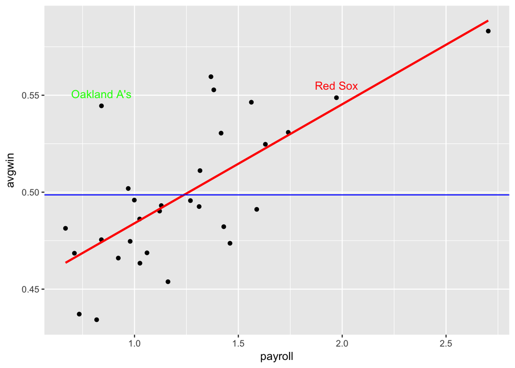

```r
ggplot(datapay, aes(x = payroll, y = avgwin)) +
  geom_point() +
  geom_smooth(method="lm", se = F,color = "red") +
  geom_hline(aes(yintercept = mean(avgwin)), color = "blue") +
  annotate(geom="text", x=0.8409340, y=0.5445067, label="Oakland A's",color="green", vjust = -1) +
  annotate(geom="text", x=1.9723587, y=0.5487172, label="Red Sox",color="red", vjust = -1)
```

Here are a few rows that show the fitted values from our model

```r
data.frame(datapay$team, datapay$payroll, datapay$avgwin, myfit0$fitted,
           myfit0$res)[15:25, ] # show a few rows
```

**HERE is how the article concludes that Beane is worth as much as the GM in Red Sox. By looking at the above plot, Oakland A’s win pct is more or less same as that of Red Sox, so based on the LS equation, the team should have paid 2 billion. Do you agree?????**

### Goodness of Fit: $R^2$

How well does the linear model fit the data? We need the following statistics from lm().

#### Residual Sum of Squares (RSS)

The least squares approach chooses $\hat\beta_0$ and $\hat\beta_1$ to minimize the RSS. RSS is defined as:

$$RSS = \sum_{i=1}^{n} \hat{\epsilon}_i^{2} = \sum_{i=1}^{n} (y_i - \hat\beta_0 - \hat\beta_1 x_i)^{2}$$

```r
  myfit0 <- lm(avgwin~payroll, data=datapay)
  RSS <- sum((myfit0$res)^2) # residual sum of squares
  RSS
```

#### Mean Sum of Squares (MSE), Residual Standard Error (RSE)

$\sigma^2$ is estimated by the Mean Sum of Squares (MSE). For simple regression, MSE is defined as:

$$MSE = \frac{RSS}{n-2}.$$

$\sigma$ is estimated by the Residual Standard Error (RSE). For simple regression, RSE is defined as:

$$RSE = \sqrt{MSE} = \sqrt{\frac{RSS}{n-2}}.$$

```r
sqrt(RSS/myfit0$df)
```

```r
summary(myfit0)$sigma
```

#### Total Sum of Squares (TSS)

TSS measures the total variance in the response Y, and can be thought of as the amount of variability inherent in the response before the regression is performed. In contrast, RSS measures the amount of variability that is left unexplained after performing the regression.

$$TSS = \sum_{i=1}^{n} (y_i - \bar{y_i})^{2}$$

```r
  TSS <- sum((datapay$avgwin-mean(datapay$avgwin))^2) # total sum of sqs
  TSS
```

#### $R^2$

$R^{2}$ measures the proportion of variability in Y that can be explained using X. An $R^{2}$ statistic that is close to 1 indicates that a large proportion of the variability in the response has been explained by the regression.

$$R^{2} = \frac{TSS - RSS}{TSS}$$

```r
(TSS-RSS)/TSS    # Percentage reduction of the total errors
```

```r
(cor(datapay$avgwin, myfit0$fit))^2 # Square of the cor between response and fitted values
```

```r
summary(myfit0)$r.squared
```

How large $R^2$ needs to be so that you are comfortable to use the linear model?

### Inference for the coefficients: $\hat\beta_1$ and $\hat\beta_0$

Under the model assumptions:

1. $y_i$ ind, normally distributed
2. The mean of $y$ given $x$ is linear
3. The variance of $y$ does not depend on $x$

The LS estimates $\hat\beta_1$ and $\hat\beta_0$ has the following properties:

1. Unbiasedness

$$\textbf{E}(\hat{\beta_1}) = \beta_1$$

2. Normality

#### Tests and CI for the coefficients

$t$-interval and $t$-test can be constructed using the above results.

For example, the 95% confidence interval for $\beta$ approximately takes the form

$$\hat\beta ± 2 \cdot SE(\hat\beta).$$

We can see below that the $SE(\beta)$ is included in the summary output

```r
summary(myfit0)
```

The `confint()` function returns the confident interval for us (95% confident interval by default).

```r
confint(myfit0)
confint(myfit0, level = 0.99)
```

### Confidence and Prediction Intervals for the mean reponse and individual repsonses

#### Confidence Interval

We use a confidence interval to quantify the uncertainty surrounding the mean of the response, i.e., `avgwin`. For example, for teams like Oakland A’s whose `payroll`=.841, a 95% Confidence Interval for the mean of response `avgwin` is

$$\hat{y}_{|x=.841} \pm t_{(\alpha/2, n-2)} \times \sqrt{MSE \times \left(\frac{1}{n} + \frac{(.841-\bar{x})^2}{\sum(x_i-\bar{x})^2}\right)}.$$

```r
new <- data.frame(payroll=c(.841))  #new <- data.frame(payroll=c(1.24))
CImean <- predict(myfit0, new, interval="confidence", se.fit=TRUE)
CImean
```

#### Prediction Interval

A prediction interval can be used to quantify the uncertainty surrounding `avgwin` for a **particular** team.

$$\hat{y}_{|x} \pm t_{(\alpha/2, n-2)} \times \sqrt{MSE \times \left( 1+\frac{1}{n} + \frac{(x-\bar{x})^2}{\sum(x_i-\bar{x})^2}\right)}$$

We now do 95% & 99% PI for a future $y$ given $x=.841$, a prediction interval

```r
new <- data.frame(payroll=c(.841))
CIpred <- predict(myfit0, new, interval="prediction", se.fit=TRUE)
CIpred

CIpred_99 <- predict(myfit0, new, interval="prediction", se.fit=TRUE, level=.99)
CIpred_99
```

From our output above, a 95% prediction interval varies from $.41$ to $.53$ for a team like the Oakland A’s. But its `avgwin` is $.54$. So it is somewhat unusual but not that unusual! Also, a 99% prediction interval would contain the true Oakland winning percentage of 0.5445067.

**Read page 82 of ILSR to fully understand the difference between confindence and prediction intervals.**

### Model diagnoses

Before using the model, we need to check the model assumptions in the following steps:

1. Check **linearity** first; if linearity is satisfied, then
2. Check **homoscedasticity**; if homoscedasticity is satisfied, then
3. Check **normality**.

#### Residual plot

We plot the residuals against the fitted values to

- check **linearity** by checking whether the residuals follow a symmetric pattern with respect to $h=0$.
- check **homoscedasticity** by checking whether the residuals are evenly distributed within a band.

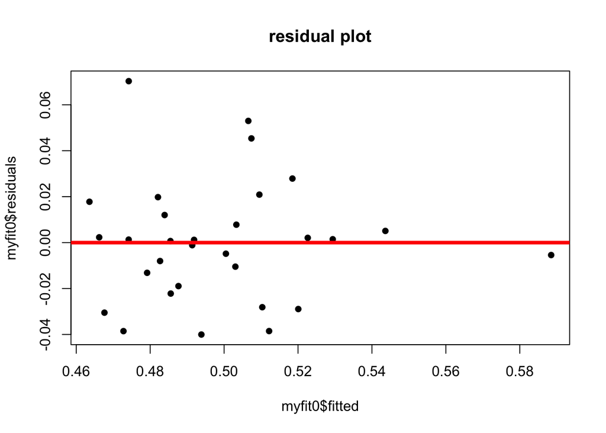

```r
plot(myfit0$fitted, myfit0$residuals,
     pch  = 16,
     main = "residual plot")
abline(h=0, lwd=4, col="red")
```

#### Check normality

We look at the qqplot of residuals to check normality.

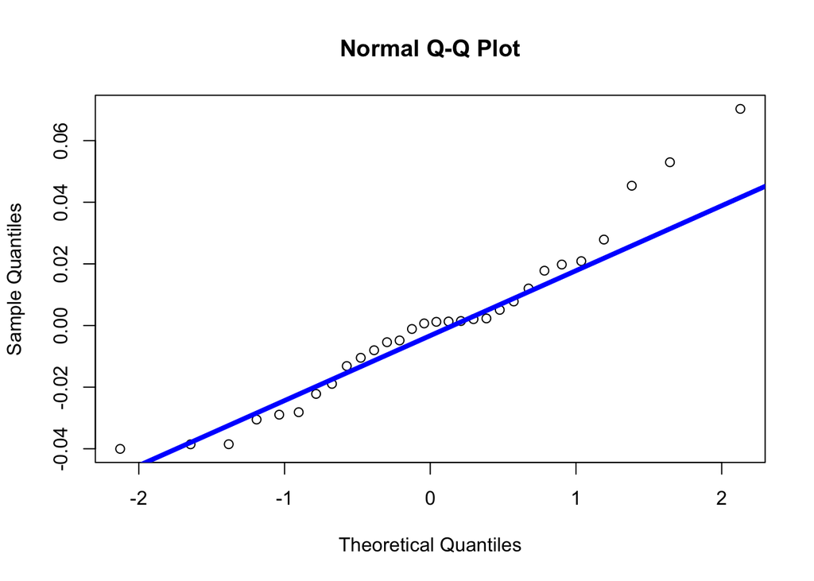

```r
  qqnorm(myfit0$residuals)
  qqline(myfit0$residuals, lwd=4, col="blue")
```

## Reverse Regression

**Warning**: one can not solve for $x$ using the above LS equation. We will show this now.

We first plot our original model:

$$y_{avgwin} = 0.42260 + 0.06137 \cdot x_{payroll}$$

```r
  par(mgp=c(1.8,.5,0), mar=c(3,3,2,1))
  plot(datapay$payroll, datapay$avgwin,
       pch  = 16,
       xlab = "Payroll",
       ylab = "Win Percentage",
       main = "MLB Teams's Overall Win Percentage vs. Payroll")
  abline(lm(avgwin ~ payroll, data=datapay), col="red", lwd=4)
```

Now, we reverse the regression and look at the summary output

```r
  myfit1 <- lm(payroll~avgwin, data=datapay)
  summary(myfit1)
```

```
##
## Call:
## lm(formula = payroll ~ avgwin, data = datapay)
##
## Residuals:
##      Min       1Q   Median       3Q      Max
## -0.76735 -0.18705 -0.03714  0.16633  0.78427
##
## Coefficients:
##             Estimate Std. Error t value Pr(>|t|)
## (Intercept)  -2.7784     0.7697  -3.610  0.00118 **
## avgwin        8.0563     1.5396   5.233 1.47e-05 ***
## ---
## Signif. codes:  0 '***' 0.001 '**' 0.01 '*' 0.05 '.' 0.1 ' ' 1
##
## Residual standard error: 0.309 on 28 degrees of freedom
## Multiple R-squared:  0.4944, Adjusted R-squared:  0.4763
## F-statistic: 27.38 on 1 and 28 DF,  p-value: 1.469e-05
```

We can now overlay our two regressions:

$$y_{payroll} = -2.7784 + 8.0563 \cdot x_{avgwin}$$

$$y_{avgwin} = 0.42260 + 0.06137 \cdot x_{payroll}$$

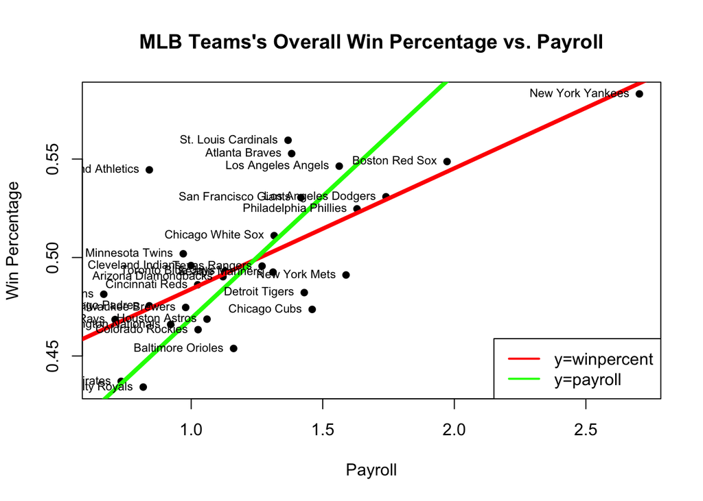

```r
  beta0 <- myfit1$coefficients[1]
  beta1 <- myfit1$coefficients[2]
  avgwin2 <- (datapay$payroll - beta0) / beta1

  plot(datapay$payroll, datapay$avgwin,
       pch  = 16,
       xlab = "Payroll",
       ylab = "Win Percentage",
       main = "MLB Teams's Overall Win Percentage vs. Payroll")
  abline(lm(avgwin ~ payroll, data=datapay), col="red", lwd=4)
  lines(datapay$payroll, avgwin2, col="green", lwd=4)
  legend("bottomright", legend=c("y=winpercent", "y=payroll"),
       lty=c(1,1), lwd=c(2,2), col=c("red","green"))
  text(datapay$payroll, datapay$avgwin, labels=datapay$team, cex=0.7, pos=2) # label teams
```

We may also want to get the LS equation w/o Oakland first.

```r
  subdata <- datapay[-20, ]
  myfit2 <- lm(avgwin ~ payroll, data=subdata)
  summary(myfit2)
```

```
##
## Call:
## lm(formula = avgwin ~ payroll, data = subdata)
##
## Residuals:
##       Min        1Q    Median        3Q       Max
## -0.037273 -0.015430  0.002040  0.009863  0.054755
##
## Coefficients:
##             Estimate Std. Error t value Pr(>|t|)
## (Intercept)  0.41311    0.01379  29.950  < 2e-16 ***
## payroll      0.06701    0.01044   6.417 7.11e-07 ***
## ---
## Signif. codes:  0 '***' 0.001 '**' 0.01 '*' 0.05 '.' 0.1 ' ' 1
##
## Residual standard error: 0.02364 on 27 degrees of freedom
## Multiple R-squared:  0.604,  Adjusted R-squared:  0.5893
## F-statistic: 41.18 on 1 and 27 DF,  p-value: 7.108e-07
```

The plot below shows the effect of Oakland on our linear model.

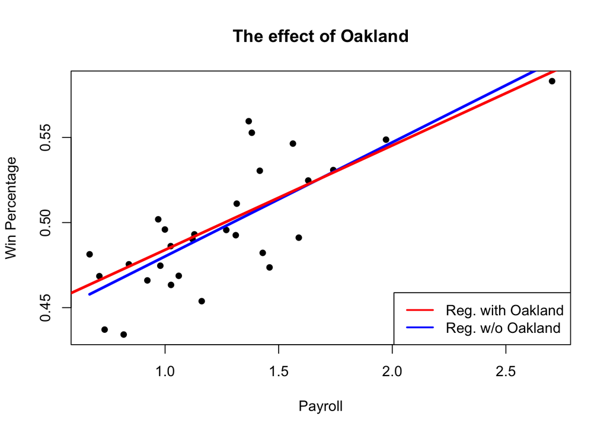

```r
  plot(subdata$payroll, subdata$avgwin,
       pch  = 16,
       xlab = "Payroll", ylab="Win Percentage",
       main = "The effect of Oakland")
  lines(subdata$payroll, predict(myfit2), col="blue", lwd=3)
  abline(myfit0, col="red", lwd=3)
  legend("bottomright", legend=c("Reg. with Oakland", "Reg. w/o Oakland"),
         lty=c(1,1), lwd=c(2,2), col=c("red","blue"))
```

We may also want to check the effect of Yankees (2.70, .58)

```r
  subdata1 <- datapay[-19, ]
  myfit3 <- lm(avgwin ~ payroll, data=subdata1)
  summary(myfit3)
```

```
##
## Call:
## lm(formula = avgwin ~ payroll, data = subdata1)
##
## Residuals:
##       Min        1Q    Median        3Q       Max
## -0.040150 -0.018782  0.000696  0.012325  0.071044
##
## Coefficients:
##             Estimate Std. Error t value Pr(>|t|)
## (Intercept)  0.41960    0.01929   21.75  < 2e-16 ***
## payroll      0.06405    0.01566    4.09 0.000349 ***
## ---
## Signif. codes:  0 '***' 0.001 '**' 0.01 '*' 0.05 '.' 0.1 ' ' 1
##
## Residual standard error: 0.02743 on 27 degrees of freedom
## Multiple R-squared:  0.3825, Adjusted R-squared:  0.3597
## F-statistic: 16.73 on 1 and 27 DF,  p-value: 0.0003489
```

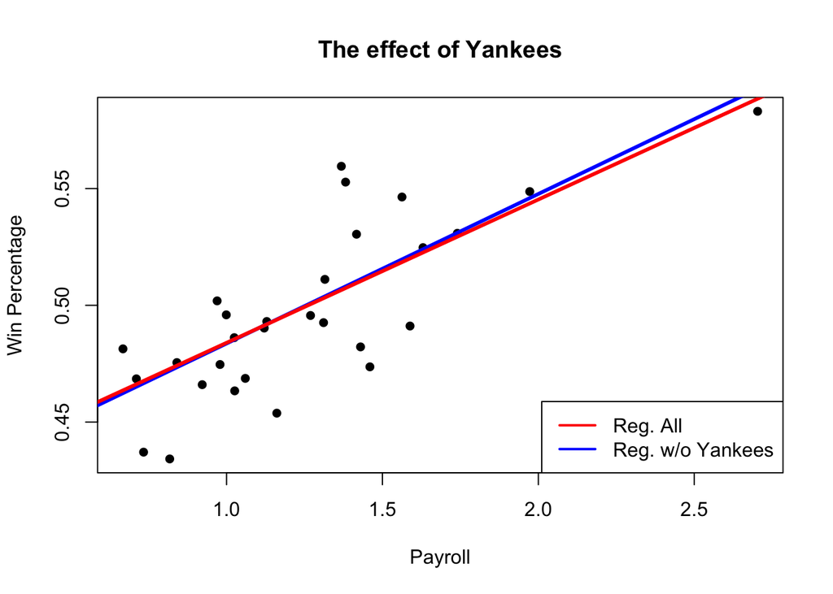

```r
  plot(subdata$payroll, subdata$avgwin,
       pch  = 16,
       xlab = "Payroll",
       ylab = "Win Percentage",
       main = "The effect of Yankees")
  abline(myfit3, col="blue", lwd=3)
  abline(myfit0, col="red", lwd=3)
  legend("bottomright", legend=c("Reg. All", "Reg. w/o Yankees"),
         lty=c(1,1), lwd=c(2,2), col=c("red","blue"))
```

## Appendix

### Appendix 1 - $t$-distribution vs $z$-distribution

Difference between $z$ and $t$ with $df=n$. The distribution of $z$ is similar to that $t$ when $df$ is large, say 30.

```r
z <- rnorm(1000)
hist(z, freq=FALSE, col="red", breaks=30, xlim=c(-5,5))
```

Check Normality

```r
qqnorm(z, pch=16, col="blue", cex=0.7)
qqline(z)   #shift-command-c  to add or to suppress comment
```

See what a $t$ variable looks like with a degrees of freedom at 10

```r
df <- 10 # you may change df
t <- rt(1000, df)   #
hist(t, freq=FALSE, col="blue", breaks=50, xlim=c(-5,5),
     main=paste("Hist of t with df=",df))
```

Make a small set of graphs to see the variability of sample from sample

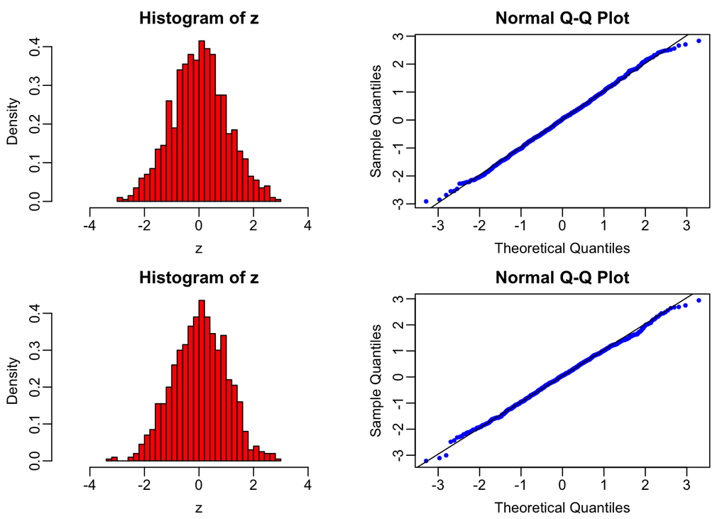

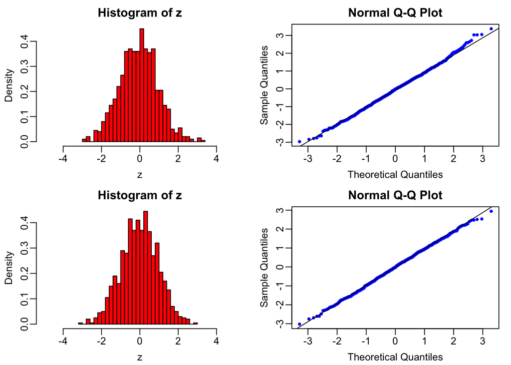

```r
# Put graphs into 2 rows and 2 cols
par(mfrow=c(2,2))

for (i in 1:4){
  z <- rnorm(1000)
  par(mgp=c(1.8,.5,0), mar=c(3,3,2,1))
  hist(z, freq=FALSE, col="red", breaks=30, xlim=c(-5,5))

  qqnorm(z, pch=16, col="blue", cex=0.7)    # check normality
  qqline(z)
}
```

### Appendix 2 - Investigate R-Squared

##### Case 1

A perfect model between X and Y but it is not linear. $R^{2}=.837$ here $y=x^{3}$ with no noise!

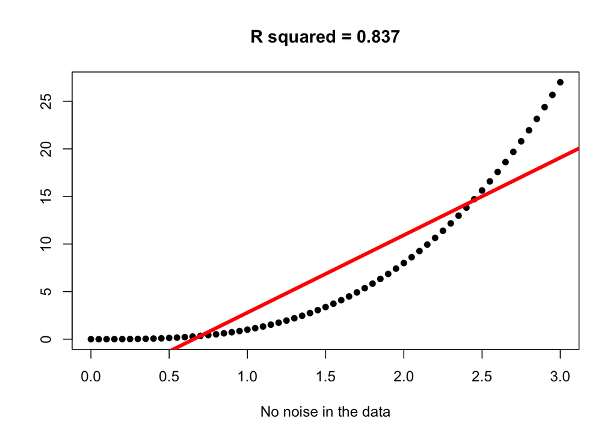

```r
x <- seq(0, 3, by=.05) # or x=seq(0, 3, length.out=61)
y <- x^3 # no variability

myfit <- lm(y ~ x)
myfit.out <- summary(myfit)
rsquared <- myfit.out$r.squared

plot(x, y, pch=16, ylab="",
   xlab = "No noise in the data",
   main = paste("R squared = ", round(rsquared, 3), sep=""))
abline(myfit, col="red", lwd=4)
```

##### Case II

A perfect linear model between X and Y but with noise here $y= 2+3x + \epsilon$, $\epsilon$ is iid N(0, var=9). Run this repeatedly

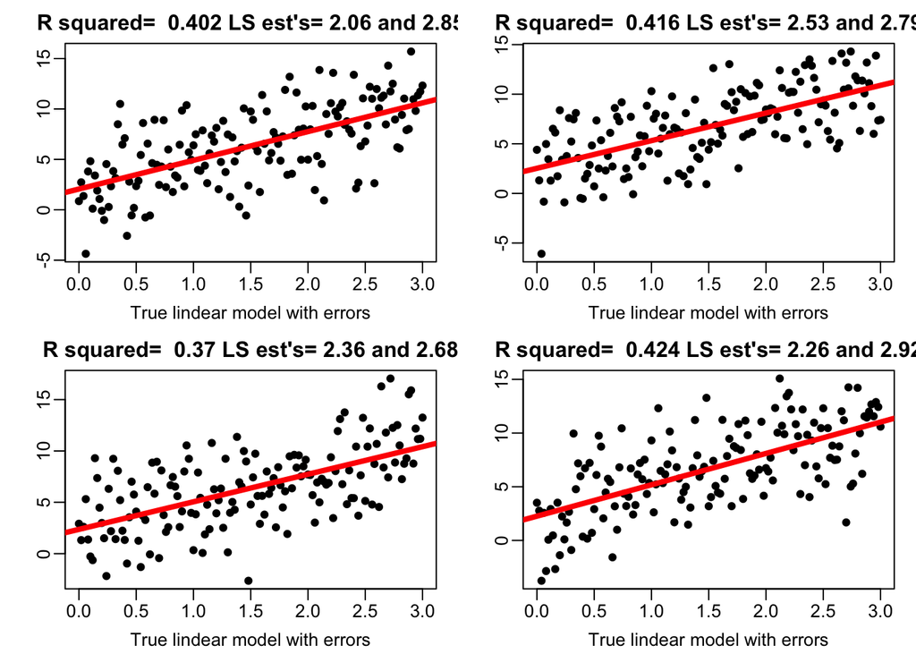

```r
par(mfrow = c(2,2))

for(i in 1:4){
  x <- seq(0, 3, by=.02)
  e <- 3*rnorm(length(x))   # Normal random errors with mean 0 and sigma=3
  y <- 2 + 3*x + 3*rnorm(length(x))

  myfit <- lm(y ~ x)
  myfit.out <- summary(myfit)
  rsquared <- round(myfit.out$r.squared,3)
  hat_beta_0 <- round(myfit$coe[1], 2)
  hat_beta_1 <- round(myfit$coe[2], 2)
  par(mgp=c(1.8,.5,0), mar=c(3,3,2,1))
  plot(x, y, pch=16, ylab="",
       xlab = "True lindear model with errors",
       main = paste("R squared= ", rsquared,
                   "LS est's=", hat_beta_0, "and", hat_beta_1))

  abline(myfit, col="red", lwd=4)
}
```

##### Case III

Same as that in Case II, but lower error to $\sigma=1$

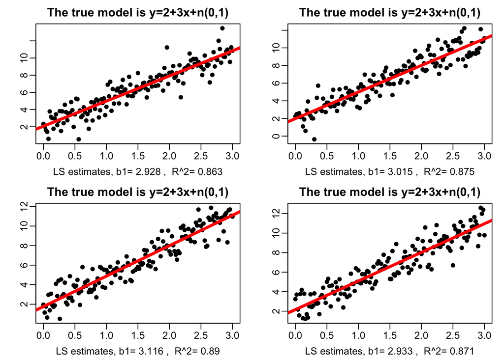

```r
par(mfrow = c(2,2))

for(i in 1:4){
  x <- seq(0, 3, by=.02)
  e <- 3*rnorm(length(x))   # Normal random errors with mean 0 and sigma=3
  y <- 2 + 3*x + 1*rnorm(length(x))

  myfit <- lm(y ~ x)
  myfit.out <- summary(myfit)
  rsquared <- round(myfit.out$r.squared, 3)
  b1 <- round(myfit.out$coe[2], 3)
  par(mgp=c(1.8,.5,0), mar=c(3,3,2,1))
  plot(x, y, pch=16,
       ylab = "",
       xlab = paste("LS estimates, b1=", b1, ",  R^2=", rsquared),
       main = "The true model is y=2+3x+n(0,1)")
  abline(myfit, col="red", lwd=4)
}
```

### Appendix 3 - More on Model Diagnoses

What do we expect to see even all the model assumptions are met?

- 1. Variability of the ls estimates $\beta$’s
- 2. Variability of the $R^{2}$’s
- 3. Model diagnoses: through residuals

We demonstrate this through a simulation.

Here is a case that all the linear model assumptions are met. Once again everything can be checked by examining the residual plots

1. Randomize X

```r
### Set up the simulations
set.seed(1)
x <- runif(100) # generate 100 random numbers from [0, 1]
```

2. Generate y only each time to see the variability of ls estimates. The true $y$ is

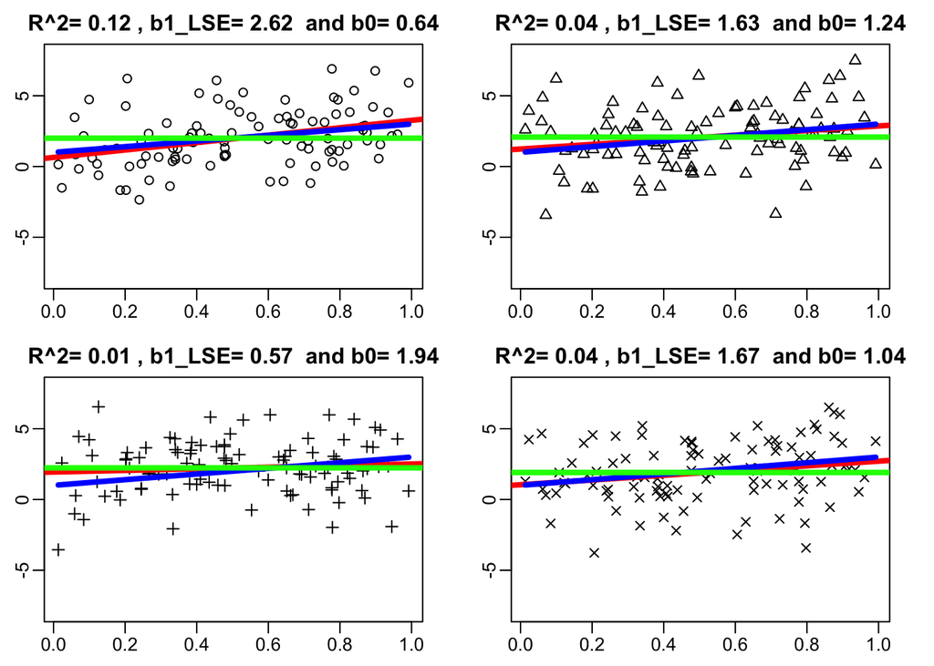

```r
# mar: c(bottom, left, top, right) to specify the margin on four sides
# mgp: specify the margin for axis title, axis labels and axis line
par(mfrow=c(2,2), mar=c(2,2,2,2), mgp=c(2,0.5,0))

for (i in 1:4) {
  y <- 1 + 2*x + rnorm(100, 0, 2) # generate response y's

  fit <- lm(y ~ x)
  fit.perfect <- summary(lm(y ~ x))
  rsquared <- round(fit.perfect$r.squared, 2)
  hat_beta_0 <- round(fit.perfect$coefficients[1], 2)
  hat_beta_1 <- round(fit.perfect$coefficients[2], 2)

  plot(x, y, pch=i,
       ylim = c(-8,8),
       xlab = "true mean: y=1+2x in blue, LS in red",
       main = paste("R^2=", rsquared,
                    ", b1_LSE=", hat_beta_1, " and b0=", hat_beta_0))
  abline(fit, lwd=4, col="red")
  lines(x, 1 + 2*x, lwd=4, col="blue")
  abline(h= mean(y), lwd=4, col="green")
}
```

The theory says that

$$\hat\beta_1 \sim \mathcal{N} (\beta_1 = 2,\, \textbf{Var}(\hat\beta_1)).$$

```r
  sigma <- 2
  n <- length(y)
  sd_b1 <- sqrt(sigma^2 /((n-1)* (sd(x))^2))  # we will estimate sigma by rse in real life.
  sd_b1
```

```
## [1] 0.7511921
```

```r
  summary(fit)
```

```
##
## Call:
## lm(formula = y ~ x)
##
## Residuals:
##     Min      1Q  Median      3Q     Max
## -5.7958 -1.1252 -0.0861  1.4240  4.0328
##
## Coefficients:
##             Estimate Std. Error t value Pr(>|t|)
## (Intercept)   1.0441     0.4607   2.266   0.0256 *
## x             1.6684     0.7913   2.108   0.0375 *
## ---
## Signif. codes:  0 '***' 0.001 '**' 0.01 '*' 0.05 '.' 0.1 ' ' 1
##
## Residual standard error: 2.107 on 98 degrees of freedom
## Multiple R-squared:  0.04339,    Adjusted R-squared:  0.03363
## F-statistic: 4.446 on 1 and 98 DF,  p-value: 0.03754
```

Plots

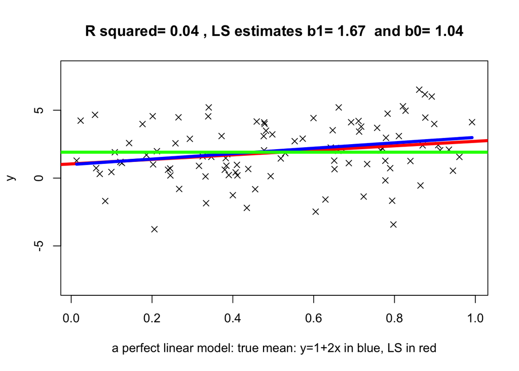

```r
  plot(x, y, pch=i,
       ylim = c(-8,8),
       xlab = "a perfect linear model: true mean: y=1+2x in blue, LS in red",
       main = paste("R squared=", rsquared,
                    ", LS estimates b1=", hat_beta_1, " and b0=", hat_beta_0))
  abline(fit, lwd=4, col="red")
  lines(x, 1 + 2*x, lwd=4, col="blue")
  abline(h= mean(y), lwd=4, col="green")
```

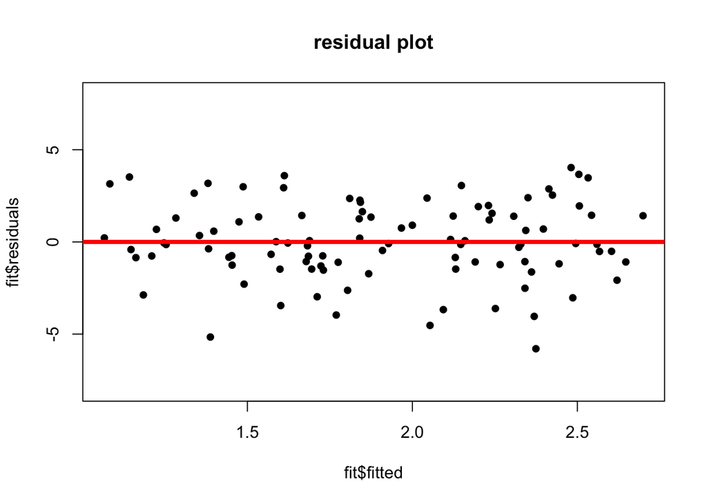

```r
  # Residuals
  plot(fit$fitted, fit$residuals,
       pch  = 16,
       ylim = c(-8, 8),
       main = "residual plot")
  abline(h=0, lwd=4, col="red")
```

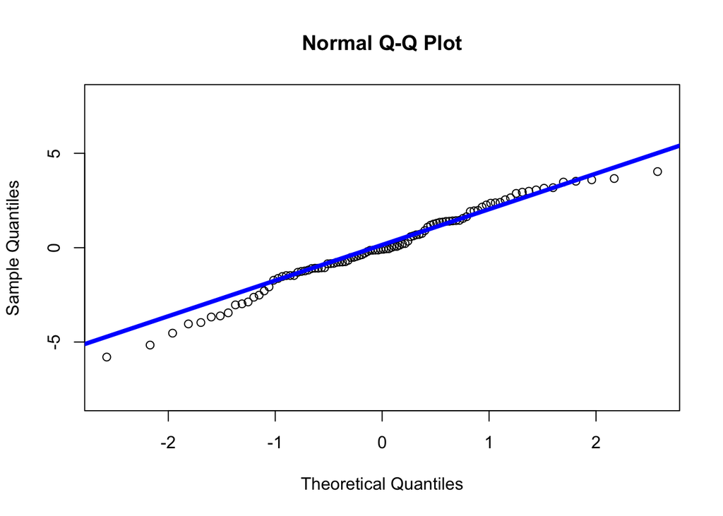

```r
  # Normality
  qqnorm(fit$residuals, ylim=c(-8, 8))
  qqline(fit$residuals, lwd=4, col="blue")
```

### Appendix 4 - Some Sample Statistics

- Sample mean:

$$\bar{y} = \frac{1}{n}\sum_{i=1}^n y_i$$

- Sample variance:

$$s^2 = \frac{\sum\limits_{i=1}^{n}(y_i – \bar{y})^2} {n – 1}$$

- Sample Standard Deviation:

$$s = \sqrt\frac{\sum\limits_{i=1}^{n}(y_i – \bar{y})^2} {n – 1}$$